# act_report

## Report: act_report

Analyzing and Visualizing the Data

The cleaned data was analyzed to answer the following questions:

**1. What source produces tweet the most?**

> **Twitter for iPhone** is the source with highest number of tweets.

| Source of Tweet | Count |
| --- | --- |
| Twitter for iPhone | 1317 |
| Twitter Web Client | 16 |
| TweetDeck | 8 |

**2. How active has the WeRateDogs twitter page been over the years?**

> The year **2016** recorded the most tweets about dogs from WeRateDogs

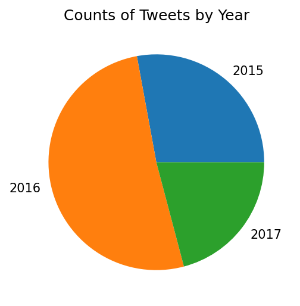

**3. Most liked dog stage by favorite count of tweets?**

> **Pupper** is the most liked dog stage according the favourite count.

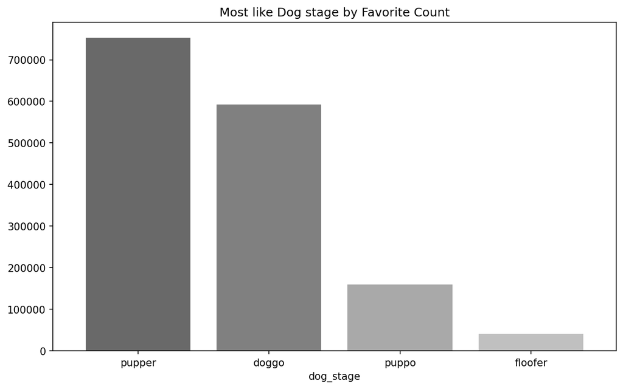

**4. What breed of dog are the most commonly predicted for the first dog?**

> **Golden Retriever** is the most commonly predicted breed of dog for the first prediction.

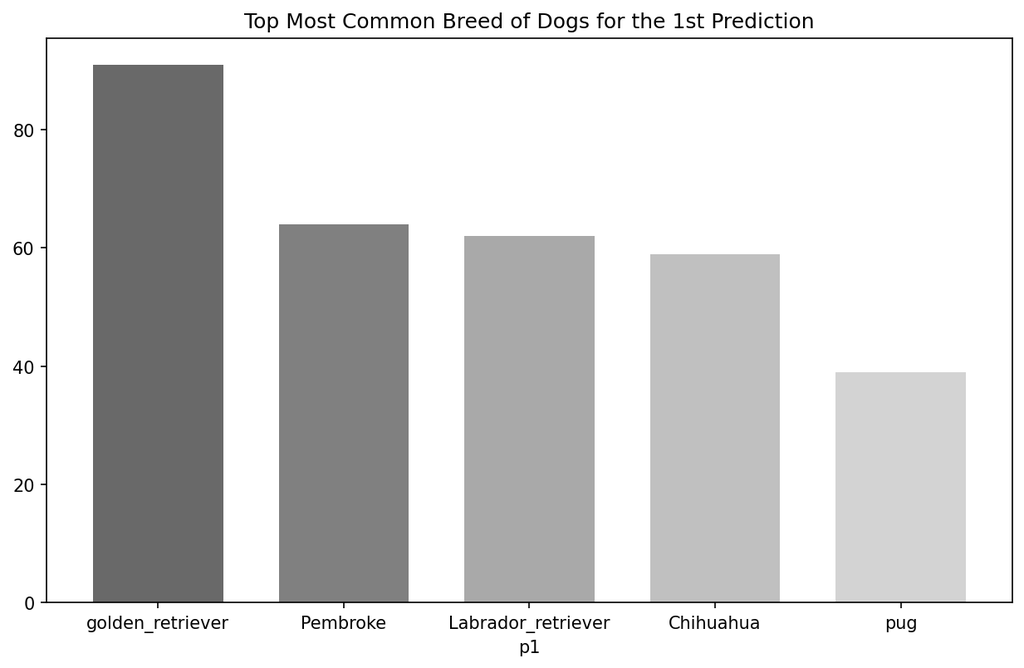

**5. Top 5 most liked photos and the dog breed in them according to first prediction**

**Most liked picture: A Chihuahua**

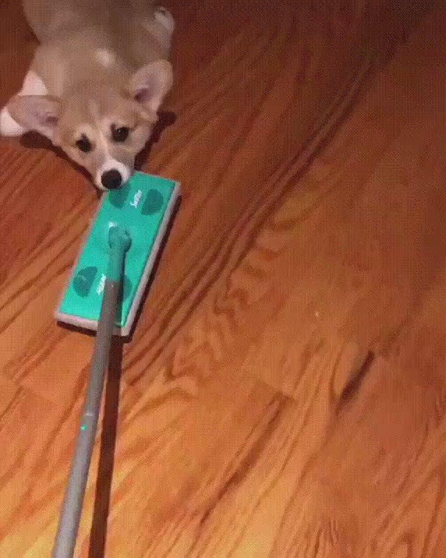

**Second most liked picture: A French Bulldog**

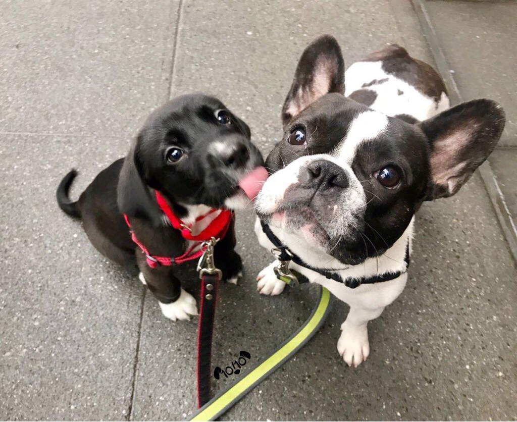

**Third most liked picture: An English Springer**

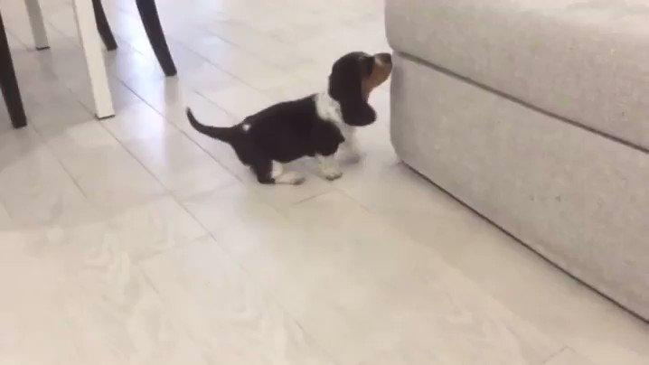

**Fourth most liked picture: A Standard Poodle**

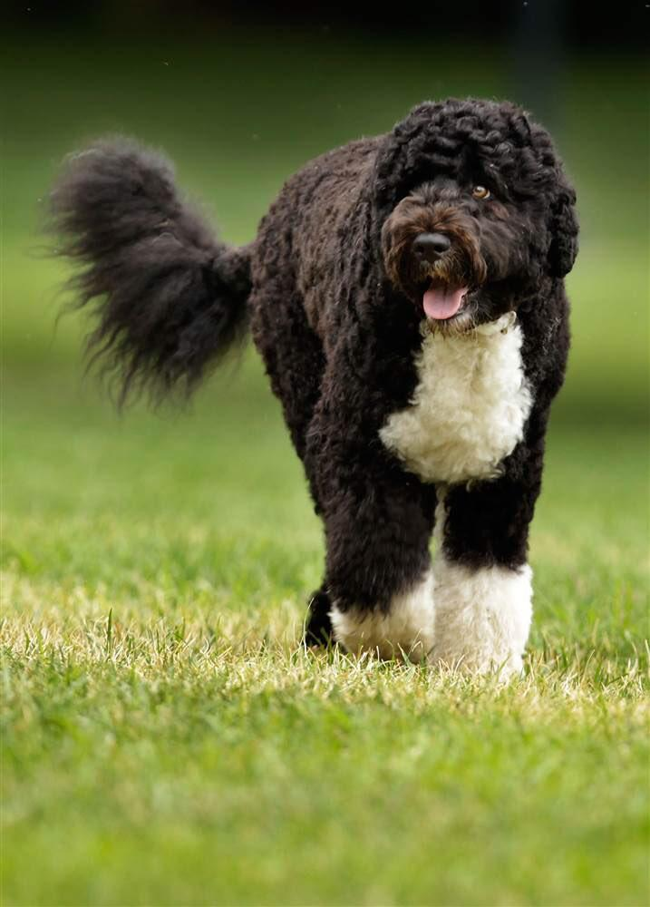

**Fifth most liked picture: A Golden Retriever**

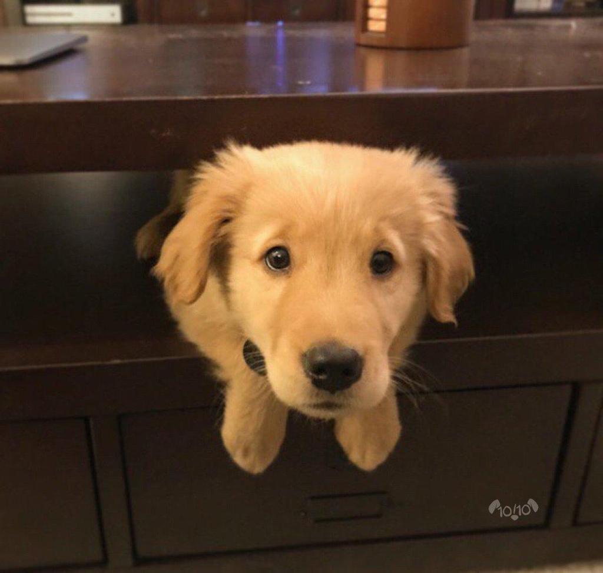